# Practical Machine Learning Project

Alexander Sanchez

1/21/2020

## Context

We use the data of the Human Activity Recognition(HAR) is collected of 6 participants that performed an exercise in 5 different ways: 1 correctly and the other 4 incorrectly. The objective of the project is to build a model that can identify in which way the excercise was executed.

## Data Exploration

We take a look to the each feature name and it’s data class.

```r
sapply(data, class)
```

```
##                        X                user_name     raw_timestamp_part_1
##                "integer"                 "factor"                "integer"
##     raw_timestamp_part_2           cvtd_timestamp               new_window
##                "integer"                 "factor"                 "factor"
##               num_window                roll_belt               pitch_belt
##                "integer"                "numeric"                "numeric"
##                 yaw_belt         total_accel_belt       kurtosis_roll_belt
##                "numeric"                "integer"                 "factor"
##      kurtosis_picth_belt        kurtosis_yaw_belt       skewness_roll_belt
##                 "factor"                 "factor"                 "factor"
##     skewness_roll_belt.1        skewness_yaw_belt            max_roll_belt
##                 "factor"                 "factor"                "numeric"
##           max_picth_belt             max_yaw_belt            min_roll_belt
##                "integer"                 "factor"                "numeric"
##           min_pitch_belt             min_yaw_belt      amplitude_roll_belt
##                "integer"                 "factor"                "numeric"
##     amplitude_pitch_belt       amplitude_yaw_belt     var_total_accel_belt
##                "integer"                 "factor"                "numeric"
##            avg_roll_belt         stddev_roll_belt            var_roll_belt
##                "numeric"                "numeric"                "numeric"
##           avg_pitch_belt        stddev_pitch_belt           var_pitch_belt
##                "numeric"                "numeric"                "numeric"
##             avg_yaw_belt          stddev_yaw_belt             var_yaw_belt
##                "numeric"                "numeric"                "numeric"
##             gyros_belt_x             gyros_belt_y             gyros_belt_z
##                "numeric"                "numeric"                "numeric"
##             accel_belt_x             accel_belt_y             accel_belt_z
##                "integer"                "integer"                "integer"
##            magnet_belt_x            magnet_belt_y            magnet_belt_z
##                "integer"                "integer"                "integer"
##                 roll_arm                pitch_arm                  yaw_arm
##                "numeric"                "numeric"                "numeric"
##          total_accel_arm            var_accel_arm             avg_roll_arm
##                "integer"                "numeric"                "numeric"
##          stddev_roll_arm             var_roll_arm            avg_pitch_arm
##                "numeric"                "numeric"                "numeric"
##         stddev_pitch_arm            var_pitch_arm              avg_yaw_arm
##                "numeric"                "numeric"                "numeric"
##           stddev_yaw_arm              var_yaw_arm              gyros_arm_x
##                "numeric"                "numeric"                "numeric"
```

[output cut: 53 more lines]

```
##                 "factor"                "integer"                "numeric"
##         avg_roll_forearm      stddev_roll_forearm         var_roll_forearm
##                "numeric"                "numeric"                "numeric"
##        avg_pitch_forearm     stddev_pitch_forearm        var_pitch_forearm
##                "numeric"                "numeric"                "numeric"
##          avg_yaw_forearm       stddev_yaw_forearm          var_yaw_forearm
##                "numeric"                "numeric"                "numeric"
##          gyros_forearm_x          gyros_forearm_y          gyros_forearm_z
##                "numeric"                "numeric"                "numeric"
##          accel_forearm_x          accel_forearm_y          accel_forearm_z
##                "integer"                "integer"                "integer"
##         magnet_forearm_x         magnet_forearm_y         magnet_forearm_z
##                "integer"                "numeric"                "numeric"
##                   classe
##                 "factor"
```

The variable that we are going to predicted is called clasee, we take a look to it.

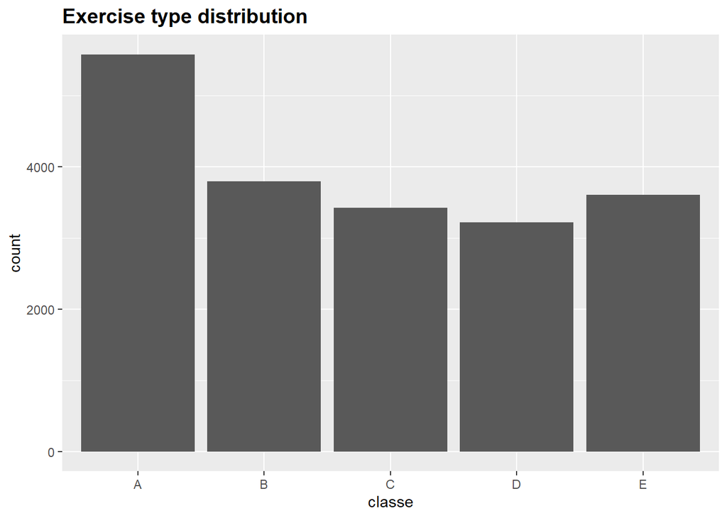

## Data Pre-processing

We remove the columns that more of 50% of their values area N/A or in blank.

```r
is50NA <- colSums(is.na(data)) < nrow(data) * 0.5
is50Empty <-  colSums((data == '')) < nrow(data) * 0.5

data <- data[ , is50NA & is50Empty ]
validation <- validation[ , is50NA & is50Empty ]
```

Then we remove the first 7 columns, because they have no relevance to the prediction.

```r
data <- data[ , -1:-7 ]
validation <- validation[ , -1:-7 ]
```

To finish the preprocesing part we take the highly correalated feature and remove the feature with the largest mean absolute correlation.

```r
set.seed(3883)
dataCorrelation <- cor(data[sapply(data,is.numeric)])
highCorrelation <- findCorrelation(dataCorrelation, cutoff=0.8, exact = TRUE)
data <- data[,-highCorrelation]
validation <- validation[,-highCorrelation]
```

Check if there is ay factor with Zero and near Zero-Variance.

```r
nzv <- nearZeroVar(data[,-53])
length(nzv)
```

```
## [1] 0
```

## Data Split

We split the data into train and test data

```r
trainIndex <- createDataPartition(data$classe, p=0.6, list=FALSE)
data_train <- data[ trainIndex,]
data_test <- data[-trainIndex,]
```

## Model Training

We use K-fold cross validation.

```r
train_control <- trainControl(method="repeatedcv", number=3, repeats=3)
```

We train the model with Classification Trees first and predict on the test data.

```r
set.seed(5665)
TreeModel <- train(classe~., data=data_train, trControl=train_control, method="rpart")
TreePedict <- predict(TreeModel, newdata = data_test)
```

Then we train the Gradient Boosting Machine and predict on the test data.

```r
set.seed(5665)
GBMModel <- train(classe~., data=data_train, trControl=train_control, method="gbm", verbose = F)
GBMPedict <- predict(GBMModel, newdata = data_test)
```

At last we train Random Forest and predict on the test data.

```r
set.seed(5665)
RFModel <- train(classe~., data=data_train, trControl=train_control, method="rf")
RFPedict <- predict(RFModel, newdata = data_test)
```

## Compare Models

we compare the resampling profiles between models.

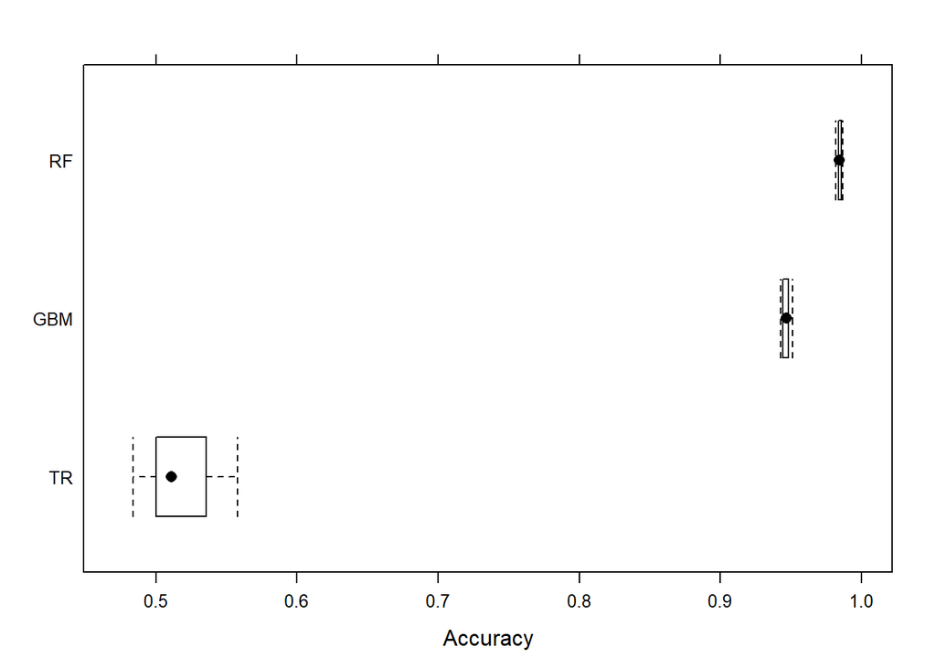

```r
resamps <- resamples(list(TR = TreeModel,
                          GBM = GBMModel,
                          RF = RFModel))

trellis.par.set(caretTheme())
bwplot(resamps, metric = "Accuracy")
```

We compare the test predictions with the actual result

```r
TreeResult <- confusionMatrix(data_test$classe, TreePedict)
TreeResult
```

```
## Confusion Matrix and Statistics
##
##           Reference
## Prediction    A    B    C    D    E
##          A 2048   25  133   26    0
##          B  653  497  312   55    1
##          C  639   52  535  140    2
##          D  504  225  122  328  107
##          E  349  246  303   56  488
##
## Overall Statistics
##
##                Accuracy : 0.4966
##                  95% CI : (0.4854, 0.5077)
##     No Information Rate : 0.5344
##     P-Value [Acc > NIR] : 1
##
##                   Kappa : 0.3413
##
##  Mcnemar's Test P-Value : <2e-16
##
## Statistics by Class:
##
##                      Class: A Class: B Class: C Class: D Class: E
## Sensitivity            0.4884  0.47560  0.38078  0.54215  0.81605
## Specificity            0.9496  0.84988  0.87067  0.86770  0.86838
## Pos Pred Value         0.9176  0.32740  0.39108  0.25505  0.33842
## Neg Pred Value         0.6179  0.91340  0.86570  0.95777  0.98282
## Prevalence             0.5344  0.13319  0.17907  0.07711  0.07622
## Detection Rate         0.2610  0.06334  0.06819  0.04180  0.06220
## Detection Prevalence   0.2845  0.19347  0.17436  0.16391  0.18379
## Balanced Accuracy      0.7190  0.66274  0.62573  0.70492  0.84222
```

```r
GBMResult <- confusionMatrix(data_test$classe, GBMPedict)
GBMResult
```

```
## Confusion Matrix and Statistics
##
##           Reference
## Prediction    A    B    C    D    E
##          A 2183   24   15    9    1
##          B   37 1413   62    4    2
##          C    0   58 1291   17    2
##          D    2    8   48 1214   14
##          E    3   12   12   27 1388
##
## Overall Statistics
##
##                Accuracy : 0.9545
##                  95% CI : (0.9497, 0.959)
##     No Information Rate : 0.2836
##     P-Value [Acc > NIR] : < 2.2e-16
##
##                   Kappa : 0.9425
##
##  Mcnemar's Test P-Value : 9.091e-09
##
## Statistics by Class:
##
##                      Class: A Class: B Class: C Class: D Class: E
## Sensitivity            0.9811   0.9327   0.9041   0.9552   0.9865
## Specificity            0.9913   0.9834   0.9880   0.9890   0.9916
## Pos Pred Value         0.9780   0.9308   0.9437   0.9440   0.9626
## Neg Pred Value         0.9925   0.9839   0.9789   0.9913   0.9970
## Prevalence             0.2836   0.1931   0.1820   0.1620   0.1793
## Detection Rate         0.2782   0.1801   0.1645   0.1547   0.1769
## Detection Prevalence   0.2845   0.1935   0.1744   0.1639   0.1838
## Balanced Accuracy      0.9862   0.9580   0.9460   0.9721   0.9891
```

The Gradient Boosting Machine accuracy is 95%

```r
RFResult <- confusionMatrix(data_test$classe, RFPedict)
RFResult
```

```
## Confusion Matrix and Statistics
##
##           Reference
## Prediction    A    B    C    D    E
##          A 2230    2    0    0    0
##          B   14 1493   11    0    0
##          C    0   14 1344   10    0
##          D    0    0   22 1264    0
##          E    0    0    0    6 1436
##
## Overall Statistics
##
##                Accuracy : 0.9899
##                  95% CI : (0.9875, 0.992)
##     No Information Rate : 0.286
##     P-Value [Acc > NIR] : < 2.2e-16
##
##                   Kappa : 0.9873
##
##  Mcnemar's Test P-Value : NA
##
## Statistics by Class:
##
##                      Class: A Class: B Class: C Class: D Class: E
## Sensitivity            0.9938   0.9894   0.9760   0.9875   1.0000
## Specificity            0.9996   0.9961   0.9963   0.9966   0.9991
## Pos Pred Value         0.9991   0.9835   0.9825   0.9829   0.9958
## Neg Pred Value         0.9975   0.9975   0.9949   0.9976   1.0000
## Prevalence             0.2860   0.1923   0.1755   0.1631   0.1830
## Detection Rate         0.2842   0.1903   0.1713   0.1611   0.1830
## Detection Prevalence   0.2845   0.1935   0.1744   0.1639   0.1838
## Balanced Accuracy      0.9967   0.9927   0.9862   0.9921   0.9995
```

The Random Forest accuracy is around 99%

## Validation

Random Forest is the most accurate model, so we predict the validate data

```r
validationPedict <- predict(RFModel, newdata = validation)
validationPedict
```

```
##  [1] B A A A A E D B A A B C B A E E A B B B
## Levels: A B C D E
```